# 第9章 方差分析

武汉大学经济与管理学院  
刘开军 博士  
Email: kjliu@whu.edu.cn

## 方差分析

- 方差分析的原理
- ANOVA模型拟合
- 单因素方差分析
- 单因素协方差分析
- 双因素方差分析
- 多元方差分析

## 方差分析的原理

在诸多领域的数量分析研究中，通常需要分析一种（或多种）因素是否能对目标结果造成影响。

例1：研究施肥量对农作物产量的影响。考虑三种施肥水平：10kg/亩、20kg/亩、40kg/亩；对每种施肥水平，随机选择10块实验田进行实验；在农作物收获时，收集每块实验田的亩产量，用方差分析就可以知道施肥量是否会影响农作物的产量。

例2：研究课后作业量对学生成绩的影响。考虑四种课后作业量：10题/天、20题/天、30题/天、40题/天；随机抽取四组学生，对每一组使用一种课后作业量；在一个月后，收集每个学生的成绩，用方差分析就可以知道课后作业量是否会影响成绩。

在这个实验中，除了课后作业量对最终成绩有影响之外，每个学生在实验之前的初始成绩也会影响最终成绩，因此在分析时应当把学生初始成绩的影响排除掉。

在方差分析中，我们将各种变量分为三类：

- 因子（或称控制变量），即在实验中可以控制的自变量，例如施肥量、课后作业量等。在方差分析中，因子只能取若干个离散值，不能取连续取。例如，施肥量只能取10、20、40。因子的每个值都称为一个因子水平，例如施肥量有3个因子水平。在R中，因子必须是factor型变量；
- 协变量。协变量也是实验中的自变量，但是协变量不能被实验人员控制，例如学生的初始成绩。在方差分析时，需要把协变量对因变量的影响剔除。在R中，协变量是连续型变量。
- 因变量（或称观察变量），即实验的结果。例如，农作物的产量、学生的成绩等。因变量可以是连续型变量。

因子与协变量x1、x2、x3、…和因变量y的关系可以表示成一个函数：

> y=f(x1, x2, x3, …)

在R的方差分析中，如果一个自变量是连续型(numeric)，那么它会被当成协变量；如果一个自变量是factor，那它会被当作因子。

根据因子和因变量的数量，方差分析可分为：

- 单因素方差分析，即只有一个因子、一个因变量的方差分析；
- 多因素方差分析，即有多个因子、一个因变量的方差分析；
- 多元方差分析，即有一个或多个因子、多个因变量的方差分析。

单因素方差分析和多因素方差分析都属于一元方差分析。

**方差分析的原理**

方差分析，是用来检验两个或多个样本的均值是否有显著差别。在R的方差分析中，因子都必须是factor类型的数据（取离散值），因子将把因变量分为若干组（即若干个样本），每个组对应一个因子水平。

方差分析认为，如果一个因子能对因变量产生显著影响，那么在不同的因子水平下，因变量的值将有显著变动；反之，如果一个因子对因变量没有显著影响，那么在不同的因子水平下，因变量值的变动就不明显。

于是，方差分析的问题就转化为检验各因子在取不同水平时，因变量的平均值是否相等。在方差分析中，原假设是：在各因子水平下，因变量的平均值都相等，备择假设是：在某个因子水平下因变量的均值与其他因子水平下因变量的均值不相等。

方差分析假设因变量服从正态分布，并且各组的方差相等，即方差分析在比较几组均值时，假设抽得的几个样本都是来自正态总体，且有一个相同的方差，仅仅均值可以不相同。

## ANOVA模型拟合

方差分析（ANalysis Of VAriance, ANOVA）与回归方法有一定联系，它们都是广义线性模型的特例。在R中，进行方差分析最常用的函数是：

result <- aov(formula, data=mydataframe)

其中，formula参数指定了各因子、协变量和因变量构成的公式，data参数指定了样本数据源，是一个数据框。在编写formula时，可以使用以下符号：

| 符号 | 用法 |
| --- | --- |
| ~ | 分隔符号，左边为因变量，右边为自变量。例如：y ~ x1 + x2 + x3 |
| + | 用于连接各自变量 |
| : | 表示自变量的交互项。例如：y ~ A + B + A:B |
| * | 表示所有可能的展开项。例如：y ~ A * B * C 等价于 y ~ A + B + C + A:B + A:C + B:C + A:B:C |
| ^ | 表示交互项的最高次数。例如，y ~ (A+B+C)^2 等价于 y ~ A + B + C + A:B + A:C + B:C |

所谓交互项是指两个或多个自变量的乘积，是公式中的非线性项。

**公式中各自变量的顺序**

在统计学中有三种常用的方差分析方法，它们处理各自变量的方式有区别。以公式

> y ~ A + B + A:B

为例，三种方差分析方法分别为：

- 类型I（序贯型），各变量的效应根据在公式中先后顺序做调整。对变量A不做调整，变量B根据变量A调整，交互项A:B根据变量A和B调整。这是aov()默认的方差分析方法。
- 类型II（分层型），各变量的效应根据同层次和低层次变量的效应做调整。变量A和B在同一层次，它们都比交互项A:B层次低，因此变量A根据变量B调整，变量B根据变量A调整，交互项A:B同时根据变量A和B调整。
- 类型III（边界型），每个效应根据模型其他各效应调整。变量A根据变量B和交互项A:B调整，变量B根据变量A和交互项A:B调整，交互项A:B根据变量A和B调整。这是SAS和SPSS默认使用的方差分析方法。

在各因子水平下，样本大小越不平衡，效应项的顺序对结果的影响越大。一般来说，越基础性的效应越需要放在公式前面，通常的顺序是：首先写协变量，之后是各个因子（越基础性的越放在前面），接着是双因素交互项，再接着是三因素的交互项，以此类推。

aov()使用序贯方差分析方法，如果想使用其他方差分析方法，可使用car::Anova()函数。

## 单因素方差分析

在单因素方差分析中，只有一个因子和一个因变量，样本将被每个因子水平分成一组，方差分析就是要检验各组的均值是否相等。

以multcomp包中的cholesterol数据集为例，这个数据集记录了50名患者接受降低胆固醇药物治疗的效果。在实验中，一共有5种治疗方法(trt)：使用传统药物20mg一天一次(记为1time)、10mg一天两次(记为2times)、5mg一天四次(记为4times)、使用新药物drugD(记为drugD)、使用新药物drugE(记为drugE)。

对每种治疗方法，随机选择10名患者接受治疗，记录下治疗前后每名患者胆固醇降低值(response)。

```r
library(multcomp)
head(cholesterol)
```

```
##     trt response
## 1 1time   3.8612
## 2 1time  10.3868
## 3 1time   5.9059
## 4 1time   3.0609
## 5 1time   7.7204
## 6 1time   2.7139
```

```r
str(cholesterol)
```

```
## 'data.frame':    50 obs. of  2 variables:
##  $ trt     : Factor w/ 5 levels "1time","2times",..: 1 1 1 1 1 1 1 1 1 1 ...
##  $ response: num  3.86 10.39 5.91 3.06 7.72 ...
```

可以看到，cholesterol$trt是一个factor，可以作为方差分析的因子。

```r
table(cholesterol$trt)
```

```
##
##  1time 2times 4times  drugD  drugE
##     10     10     10     10     10
```

```r
aggregate(cholesterol$response, by=list(cholesterol$trt), FUN=mean)
```

```
##   Group.1        x
## 1   1time  5.78197
## 2  2times  9.22497
## 3  4times 12.37478
## 4   drugD 15.36117
## 5   drugE 20.94752
```

```r
aggregate(cholesterol$response, by=list(cholesterol$trt), FUN=sd)
```

```
##   Group.1        x
## 1   1time 2.878113
## 2  2times 3.483054
## 3  4times 2.923119
## 4   drugD 3.454636
## 5   drugE 3.345003
```

```r
myfit <- aov(response ~ trt, data=cholesterol)
myfit
```

```
## Call:
##    aov(formula = response ~ trt, data = cholesterol)
##
## Terms:
##                       trt Residuals
## Sum of Squares  1351.3690  468.7504
## Deg. of Freedom         4        45
##
## Residual standard error: 3.227488
## Estimated effects may be unbalanced
```

```r
summary(myfit)
```

```
##             Df Sum Sq Mean Sq F value   Pr(>F)
## trt          4 1351.4   337.8   32.43 9.82e-13 ***
## Residuals   45  468.8    10.4
## ---
## Signif. codes:  0 '***' 0.001 '**' 0.01 '*' 0.05 '.' 0.1 ' ' 1
```

可以看到，显著性水平为9.82e-13 < 0.01，因此可以拒绝原假设，认为这5种治疗方法对降低胆固醇的疗效有显著差异。

我们可以使用gplots包中的plotmeans()来绘制出带有置信区间的组均值图形，可以清楚地看到各组患者的差异。

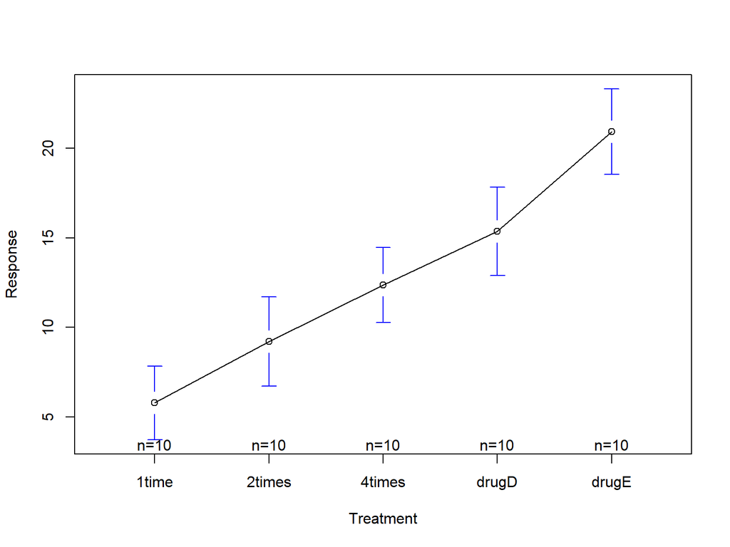

```r
library(gplots)
plotmeans(response ~ trt, data=cholesterol, xlab="Treatment", ylab="Response")
```

**多重比较**

在前面的例子中，aov()函数从整体上检验了各组患者的差异，告诉了这5组患者的疗效是有差异的，但并没有具体是哪组患者与其他患者有差异。

我们可以使用多重比较来解决这个问题，例如可以使用TukeyHSD()函数进行两两比较。

```r
myfit <- aov(response ~ trt, data=cholesterol)
TukeyHSD(myfit)
```

```
##   Tukey multiple comparisons of means
##     95% family-wise confidence level
##
## Fit: aov(formula = response ~ trt, data = cholesterol)
##
## $trt
##                   diff        lwr       upr     p adj
## 2times-1time   3.44300 -0.6582817  7.544282 0.1380949
## 4times-1time   6.59281  2.4915283 10.694092 0.0003542
## drugD-1time    9.57920  5.4779183 13.680482 0.0000003
## drugE-1time   15.16555 11.0642683 19.266832 0.0000000
## 4times-2times  3.14981 -0.9514717  7.251092 0.2050382
## drugD-2times   6.13620  2.0349183 10.237482 0.0009611
## drugE-2times  11.72255  7.6212683 15.823832 0.0000000
## drugD-4times   2.98639 -1.1148917  7.087672 0.2512446
## drugE-4times   8.57274  4.4714583 12.674022 0.0000037
## drugE-drugD    5.58635  1.4850683  9.687632 0.0030633
```

可以看到，1time和2times、2times和4times、4times和drugD的差异不显著(p>0.05)，其他都有显著差异。

对于1time和2times这两种疗法，两组患者response均值之差为3.44，均值之差的95%置信区间为[-0.658, 7.54]，并且从显著性水平p-value=0.138>0.05，可以判断这两种疗法没有显著差异。而4times和1times这两种疗法有显著差异，4times的疗效更好。

## 单因素协方差分析

在单因素协方差分析中，有一个因子，以及一个或多个协变量。

以multcomp包中的litter数据框为例，该数据框记录了药物对老鼠产崽的影响。在实验中，取74只怀孕的母鼠，对它们使用药物，之后记录下产崽时，每窝幼崽的数量和平均体重。

该数据框有4列：dose表示用药量(取值0, 5, 50, 500)，number表示一窝幼崽的数量，weight表示一窝幼崽的平均体重，gesttime表示怀孕时间长度。

在实验中，除了用药量(dose)会影响幼崽的体重(weight)之外，怀孕时长(gesttime)和一窝幼崽的数量(number)也会影响幼崽的体重。实验中，用药量(dose)是控制变量，作为因子，怀孕时长(gesttime)和一窝幼崽的数量(number)是协变量，幼崽的体重(weight)作为因变量。

```r
library(multcomp)
str(litter)
```

```
## 'data.frame':    74 obs. of  4 variables:
##  $ dose    : Factor w/ 4 levels "0","5","50","500": 1 1 1 1 1 1 1 1 1 1 ...
##  $ weight  : num  28.1 33.3 36.4 35.5 36.8 ...
##  $ gesttime: num  22.5 22.5 22 22 21.5 23 21.5 22.5 22.5 21.5 ...
##  $ number  : int  15 14 14 13 15 5 16 15 14 15 ...
```

```r
table(litter$dose)
```

```
##
##   0   5  50 500
##  20  19  18  17
```

```r
aggregate(litter$weight, by=list(litter$dose), FUN=mean)
```

```
##   Group.1        x
## 1       0 32.30850
## 2       5 29.30842
## 3      50 29.86611
## 4     500 29.64647
```

```r
myfit <- aov(weight ~ number + gesttime + dose, data=litter)
summary(myfit)
```

```
##             Df Sum Sq Mean Sq F value  Pr(>F)
## number       1   69.8   69.77   4.367 0.04038 *
## gesttime     1  143.7  143.70   8.994 0.00378 **
## dose         3  122.8   40.93   2.562 0.06196 .
## Residuals   68 1086.4   15.98
## ---
## Signif. codes:  0 '***' 0.001 '**' 0.01 '*' 0.05 '.' 0.1 ' ' 1
```

可以看到，在0.05水平下，两个协变量number和gesttime都对weight有显著影响，而在控制了number和gesttime之后，dose对weight的影响不显著。

## 双因素方差分析

在双因素方差分析中，存在两个因子。这两个因子除了各自影响因变量（主效应）之外，还会存在交互效应，因此在双因素方差分析的公式中，需要加上交互项。双因素方差分析一般写为：

> myfit <- aov(y ~ x1 + x2 + x1:x2, data=mydataframe)

或者简写为：

> myfit <- aov(y ~ x1*x2, data=mydataframe)

以基础安装包中的ToothGrowth数据框为例，该数据框记录了维生素C和喂食方式对海豚牙齿生长的影响。在实验中，分别对60只海豚喂食两种食物：橙汁(orange juice)或抗坏血酸维生素C(ascorbic acid)，在食物中的维生素C(Vitamin C)含量有三个水平：0.5mg、1mg或2mg，一段时间后记录下海豚牙齿的长度。

数据框ToothGrowth有3列：len表示海豚牙齿的长度，supp表示食物类型(VC或OJ)，dose表示VC含量(0.5, 1, 2)。supp是一个factor，可以直接放入方差分析，但dose是一个numeric vector，需要先把它转换成一个factor。

```r
str(ToothGrowth)
```

```
## 'data.frame':    60 obs. of  3 variables:
##  $ len : num  4.2 11.5 7.3 5.8 6.4 10 11.2 11.2 5.2 7 ...
##  $ supp: Factor w/ 2 levels "OJ","VC": 2 2 2 2 2 2 2 2 2 2 ...
##  $ dose: num  0.5 0.5 0.5 0.5 0.5 0.5 0.5 0.5 0.5 0.5 ...
```

```r
ToothGrowth$dose <- factor(ToothGrowth$dose)
xtabs(~supp+dose, data=ToothGrowth)
```

```
##     dose
## supp 0.5  1  2
##   OJ  10 10 10
##   VC  10 10 10
```

```r
aggregate(len ~ supp + dose, data=ToothGrowth, FUN=mean)
```

```
##   supp dose   len
## 1   OJ  0.5 13.23
## 2   VC  0.5  7.98
## 3   OJ    1 22.70
## 4   VC    1 16.77
## 5   OJ    2 26.06
## 6   VC    2 26.14
```

```r
aggregate(len ~ supp + dose, data=ToothGrowth, FUN=sd)
```

```
##   supp dose      len
## 1   OJ  0.5 4.459709
## 2   VC  0.5 2.746634
## 3   OJ    1 3.910953
## 4   VC    1 2.515309
## 5   OJ    2 2.655058
## 6   VC    2 4.797731
```

```r
myfit <- aov(len ~ supp*dose, data=ToothGrowth)
summary(myfit)
```

```
##             Df Sum Sq Mean Sq F value   Pr(>F)
## supp         1  205.4   205.4  15.572 0.000231 ***
## dose         2 2426.4  1213.2  92.000  < 2e-16 ***
## supp:dose    2  108.3    54.2   4.107 0.021860 *
## Residuals   54  712.1    13.2
## ---
## Signif. codes:  0 '***' 0.001 '**' 0.01 '*' 0.05 '.' 0.1 ' ' 1
```

可以看到，两个主效应都非常显著，表明supp和dose都对len有显著影响；交互效应在0.05水平下显著，这表明supp(或dose)对len的影响程度受到dose(或supp)的调节。

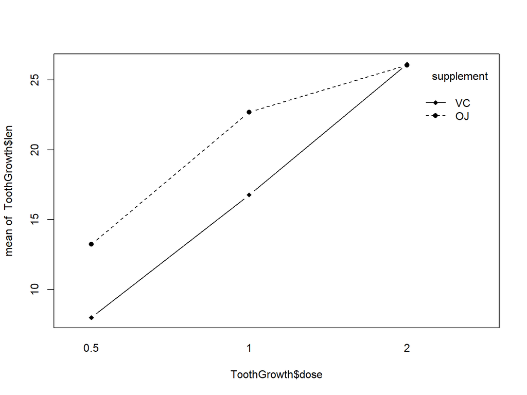

```r
interaction.plot(ToothGrowth$dose, ToothGrowth$supp, ToothGrowth$len,
                 type="b", pch=c(16, 18), trace.label="supplement")
```

## 多元方差分析

多元方差分析中存在多个因变量，先将这些因变量组成一个向量，之后调用函数manova()，方法为：

myfit <- manova(formula, data=mydataframe)

以MASS包中的UScereal为例。该数据框随机抽取某零售商货架上放置的65种谷物食品，记录下食品的制造商(mfr)、在货架上在位置(shelf)、各营养成份(calories, protein, fat等)。

我们以UScereal数据框为例，检验不同制造商、不同货架层(shelf=1, 2, 3)上的食品，它们的营养成份(作为示例，我们只选取calories、fat和sugars三种营养成份)是否有区别，这是一个双因素三元方差分析过程。

```r
library(MASS)
str(UScereal)
```

```
## 'data.frame':    65 obs. of  11 variables:
##  $ mfr      : Factor w/ 6 levels "G","K","N","P",..: 3 2 2 1 2 1 6 4 5 1 ...
##  $ calories : num  212 212 100 147 110 ...
##  $ protein  : num  12.12 12.12 8 2.67 2 ...
##  $ fat      : num  3.03 3.03 0 2.67 0 ...
##  $ sodium   : num  394 788 280 240 125 ...
##  $ fibre    : num  30.3 27.3 28 2 1 ...
##  $ carbo    : num  15.2 21.2 16 14 11 ...
##  $ sugars   : num  18.2 15.2 0 13.3 14 ...
##  $ shelf    : int  3 3 3 1 2 3 1 3 2 1 ...
##  $ potassium: num  848.5 969.7 660 93.3 30 ...
##  $ vitamins : Factor w/ 3 levels "100%","enriched",..: 2 2 2 2 2 2 2 2 2 2 ...
```

```r
UScereal$shelf <- factor(UScereal$shelf)  #需要先将shelf转换成factor
table(UScereal$mfr)
```

```
##
##  G  K  N  P  Q  R
## 22 21  3  9  5  5
```

```r
table(UScereal$shelf)
```

```
##
##  1  2  3
## 18 18 29
```

```r
xtabs(~mfr+shelf, data=UScereal)
```

```
##    shelf
## mfr  1  2  3
##   G  6  7  9
##   K  4  7 10
##   N  2  0  1
##   P  2  1  6
##   Q  0  3  2
##   R  4  0  1
```

```r
aggregate(cbind(calories, fat, sugars) ~ mfr + shelf, data=UScereal, FUN=mean)
```

```
##    mfr shelf  calories       fat    sugars
## 1    G     1 121.33334 1.4888889  7.855556
## 2    K     1 116.66667 0.0000000  5.666667
## 3    N     1 134.32836 0.0000000  0.000000
## 4    P     1  98.17157 0.0000000 12.658066
## 5    R     1 122.73180 0.7462686  4.550687
## 6    G     2 117.14286 1.4285714 10.857143
## 7    K     2 134.39588 0.7370291 13.883262
## 8    P     2 146.66667 1.3333333 16.000000
## 9    Q     2 143.08458 2.5505804 11.985075
## 10   G     3 164.81481 2.2592593 10.888889
## 11   K     3 173.56536 1.6333785 10.691271
## 12   N     3 212.12121 3.0303030 18.181818
## 13   P     3 234.96834 2.4508141 12.181102
## 14   Q     3 125.00000 1.0000000  6.000000
## 15   R     3 133.33333 0.0000000  6.666667
```

```r
myfit <- manova(cbind(calories, fat, sugars) ~ mfr * shelf, data=UScereal)
summary(myfit)
```

```
##           Df  Pillai approx F num Df den Df   Pr(>F)
## mfr        5 0.39756   1.5276     15    150 0.101937
## shelf      2 0.39108   3.9701      6     98 0.001345 **
## mfr:shelf  7 0.34404   0.9252     21    150 0.559353
## Residuals 50
## ---
## Signif. codes:  0 '***' 0.001 '**' 0.01 '*' 0.05 '.' 0.1 ' ' 1
```

在0.01水平下，mfr没有显著影响，即各制造商生产的食品营养成份无显著差异；shelf有显著影响，即不同货架层上放置的食品是显著不同的。

我们可以分别察看对每种营养成份的检验结果，即对每种营养成份进行双因素方差分析。

```r
summary.aov(myfit)
```

```
##  Response calories :
##             Df Sum Sq Mean Sq F value  Pr(>F)
## mfr          5  25769  5153.7  1.5574 0.18932
## shelf        2  40334 20167.2  6.0944 0.00428 **
## mfr:shelf    7  17736  2533.8  0.7657 0.61850
## Residuals   50 165456  3309.1
## ---
## Signif. codes:  0 '***' 0.001 '**' 0.01 '*' 0.05 '.' 0.1 ' ' 1
##
##  Response fat :
##             Df  Sum Sq Mean Sq F value  Pr(>F)
## mfr          5  12.602  2.5205  0.9661 0.44753
## shelf        2  15.319  7.6596  2.9360 0.06229 .
## mfr:shelf    7  15.293  2.1848  0.8374 0.56165
## Residuals   50 130.443  2.6089
## ---
## Signif. codes:  0 '***' 0.001 '**' 0.01 '*' 0.05 '.' 0.1 ' ' 1
##
##  Response sugars :
##             Df  Sum Sq Mean Sq F value  Pr(>F)
## mfr          5  253.14  50.628  1.7643 0.13738
## shelf        2  260.76 130.380  4.5437 0.01538 *
## mfr:shelf    7  230.56  32.937  1.1478 0.34932
## Residuals   50 1434.75  28.695
## ---
## Signif. codes:  0 '***' 0.001 '**' 0.01 '*' 0.05 '.' 0.1 ' ' 1
```

## Do It Yourself

- 单因素方差分析中，对假设条件（正态性、等方差性）的检验方法；
- 单因素协方差分析中，对假设条件的检验方法；
- 进行重复测量方差分析的方法；

回答：

- 在multcomp::litter中，分别考虑不使用协变量、只使用gesttime作为协变量、使用gesttime和number作为协变量，检验dose对weight的影响，看看结论有何变化？哪个结论更合理？
- 在MASS::UScereal中，货架上哪一层的食品营养含量最高？

思考：

- 能够用线性回归完成方差分析的功能吗？
- t检验与方差分析有何异同点？